# Risk Factor Analysis

## Outcome Variable

**Outcome Variable:** ever_stunted

## Predictor Variables

**Intervention Variable:** nrooms

**Adjustment Set:**

unadjusted

## Stratifying Variables

The analysis was stratified on these variable(s):

- agecat
- studyid

The following strata were considered:

- agecat: 12 months, studyid: ki0047075b-MAL-ED
- agecat: 12 months, studyid: ki1000108-CMC-V-BCS-2002
- agecat: 12 months, studyid: ki1000108-IRC
- agecat: 12 months, studyid: ki1017093b-PROVIDE
- agecat: 12 months, studyid: ki1017093c-NIH-Crypto
- agecat: 12 months, studyid: ki1113344-GMS-Nepal
- agecat: 12 months, studyid: ki1114097-CONTENT
- agecat: 12 months, studyid: ki1135781-COHORTS
- agecat: 18 months, studyid: ki0047075b-MAL-ED
- agecat: 18 months, studyid: ki1000108-CMC-V-BCS-2002
- agecat: 18 months, studyid: ki1000108-IRC
- agecat: 18 months, studyid: ki1017093b-PROVIDE
- agecat: 18 months, studyid: ki1017093c-NIH-Crypto
- agecat: 18 months, studyid: ki1113344-GMS-Nepal
- agecat: 18 months, studyid: ki1114097-CONTENT
- agecat: 24 months, studyid: ki0047075b-MAL-ED
- agecat: 24 months, studyid: ki1000108-CMC-V-BCS-2002
- agecat: 24 months, studyid: ki1000108-IRC
- agecat: 24 months, studyid: ki1017093b-PROVIDE
- agecat: 24 months, studyid: ki1017093c-NIH-Crypto
- agecat: 24 months, studyid: ki1113344-GMS-Nepal
- agecat: 24 months, studyid: ki1114097-CONTENT
- agecat: 3 months, studyid: ki0047075b-MAL-ED
- agecat: 3 months, studyid: ki1000108-CMC-V-BCS-2002
- agecat: 3 months, studyid: ki1000108-IRC
- agecat: 3 months, studyid: ki1017093b-PROVIDE
- agecat: 3 months, studyid: ki1017093c-NIH-Crypto
- agecat: 3 months, studyid: ki1113344-GMS-Nepal
- agecat: 3 months, studyid: ki1114097-CONTENT
- agecat: 3 months, studyid: ki1135781-COHORTS
- agecat: 6 months, studyid: ki0047075b-MAL-ED
- agecat: 6 months, studyid: ki1000108-CMC-V-BCS-2002
- agecat: 6 months, studyid: ki1000108-IRC
- agecat: 6 months, studyid: ki1017093b-PROVIDE
- agecat: 6 months, studyid: ki1017093c-NIH-Crypto
- agecat: 6 months, studyid: ki1113344-GMS-Nepal
- agecat: 6 months, studyid: ki1114097-CONTENT

### Dropped Strata

Some strata were dropped due to rare outcomes:

- agecat: 3 months, studyid: ki1000108-CMC-V-BCS-2002
- agecat: 3 months, studyid: ki1017093b-PROVIDE
- agecat: 6 months, studyid: ki1017093b-PROVIDE
- agecat: 12 months, studyid: ki1000108-CMC-V-BCS-2002
- agecat: 12 months, studyid: ki1017093b-PROVIDE
- agecat: 18 months, studyid: ki1000108-CMC-V-BCS-2002
- agecat: 18 months, studyid: ki1017093b-PROVIDE
- agecat: 24 months, studyid: ki1000108-CMC-V-BCS-2002
- agecat: 24 months, studyid: ki1000108-IRC
- agecat: 24 months, studyid: ki1017093b-PROVIDE

## Methods Detail

We’re interested in the causal parameters $E[Y_a]$ for all values of $a \in \mathcal{A}$. These parameters represent the mean outcome if, possibly contrary to fact, we intervened to set all units to have $A=a$. Under the randomization and positivity assumptions, these are identified by the statistical parameters $\psi_a=E_W[E_{Y|A,W}(Y|A=a,W)]$. In addition, we’re interested in the mean of $Y$, $E[Y]$ under no intervention (the observed mean). We will estimate these parameters by using SuperLearner to fit the relevant likelihood factors – $E_{Y|A,W}(Y|A=a,W)$ and $p(A=a|W)$, and then updating our likelihood fit using a joint TMLE.

For unadjusted analyses ($W=\{\}$), initial likelihoods were estimated using Lrnr_glm to estimate the simple $E(Y|A)$ and Lrnr_mean to estimate $p(A)$. For adjusted analyses, a small library containing Lrnr_glmnet, Lrnr_xgboost, and Lrnr_mean was used.

Having estimated these parameters, we will then use the delta method to estimate relative risks and attributable risks relative to a prespecified baseline level of $A$.

# Results Detail

## Results Plots

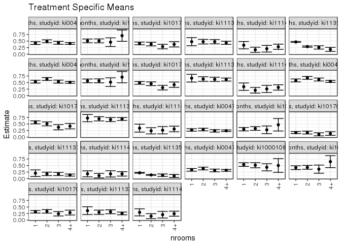

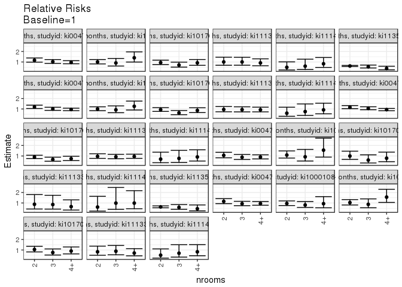

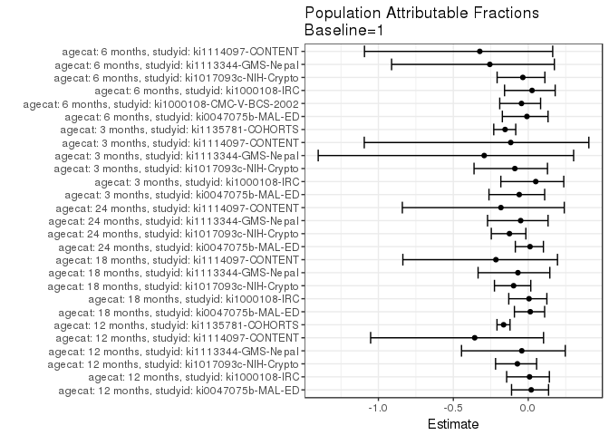

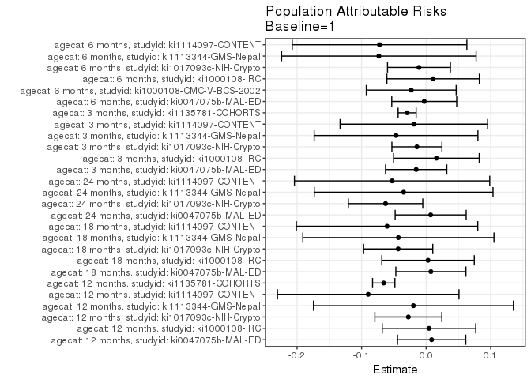

## Data Summary

| agecat | studyid | A | n | nA | nAY0 | nAY1 |
| --- | --- | --- | --- | --- | --- | --- |
| 3 months | ki0047075b-MAL-ED | 1 | 1702 | 338 | 246 | 92 |
| 3 months | ki0047075b-MAL-ED | 2 | 1702 | 316 | 225 | 91 |
| 3 months | ki0047075b-MAL-ED | 3 | 1702 | 310 | 236 | 74 |
| 3 months | ki0047075b-MAL-ED | 4+ | 1702 | 738 | 558 | 180 |
| 3 months | ki1000108-CMC-V-BCS-2002 | 1 | 362 | 196 | 128 | 68 |
| 3 months | ki1000108-CMC-V-BCS-2002 | 2 | 362 | 101 | 63 | 38 |
| 3 months | ki1000108-CMC-V-BCS-2002 | 3 | 362 | 51 | 35 | 16 |
| 3 months | ki1000108-CMC-V-BCS-2002 | 4+ | 362 | 14 | 11 | 3 |
| 3 months | ki1000108-IRC | 1 | 408 | 185 | 129 | 56 |
| 3 months | ki1000108-IRC | 2 | 408 | 170 | 114 | 56 |
| 3 months | ki1000108-IRC | 3 | 408 | 36 | 26 | 10 |
| 3 months | ki1000108-IRC | 4+ | 408 | 17 | 9 | 8 |
| 3 months | ki1017093b-PROVIDE | 1 | 175 | 124 | 92 | 32 |
| 3 months | ki1017093b-PROVIDE | 2 | 175 | 27 | 21 | 6 |
| 3 months | ki1017093b-PROVIDE | 3 | 175 | 17 | 13 | 4 |
| 3 months | ki1017093b-PROVIDE | 4+ | 175 | 7 | 5 | 2 |
| 3 months | ki1017093c-NIH-Crypto | 1 | 758 | 368 | 304 | 64 |
| 3 months | ki1017093c-NIH-Crypto | 2 | 758 | 191 | 158 | 33 |
| 3 months | ki1017093c-NIH-Crypto | 3 | 758 | 104 | 93 | 11 |
| 3 months | ki1017093c-NIH-Crypto | 4+ | 758 | 95 | 82 | 13 |
| 3 months | ki1113344-GMS-Nepal | 1 | 593 | 39 | 31 | 8 |
| 3 months | ki1113344-GMS-Nepal | 2 | 593 | 128 | 105 | 23 |
| 3 months | ki1113344-GMS-Nepal | 3 | 593 | 149 | 123 | 26 |
| 3 months | ki1113344-GMS-Nepal | 4+ | 593 | 277 | 240 | 37 |
| 3 months | ki1114097-CONTENT | 1 | 215 | 44 | 36 | 8 |
| 3 months | ki1114097-CONTENT | 2 | 215 | 54 | 48 | 6 |
| 3 months | ki1114097-CONTENT | 3 | 215 | 39 | 32 | 7 |
| 3 months | ki1114097-CONTENT | 4+ | 215 | 78 | 64 | 14 |
| 3 months | ki1135781-COHORTS | 1 | 5193 | 3403 | 2654 | 749 |
| 3 months | ki1135781-COHORTS | 2 | 5193 | 1501 | 1294 | 207 |

[output cut: 130 more lines]

## Results Table

### Parameter: TSM

| agecat | studyid | intervention_level | baseline_level | estimate | ci_lower | ci_upper |
| --- | --- | --- | --- | --- | --- | --- |
| 3 months | ki0047075b-MAL-ED | 1 | NA | 0.2721893 | 0.2247256 | 0.3196531 |
| 3 months | ki0047075b-MAL-ED | 2 | NA | 0.2879747 | 0.2380337 | 0.3379157 |
| 3 months | ki0047075b-MAL-ED | 3 | NA | 0.2387097 | 0.1912412 | 0.2861781 |
| 3 months | ki0047075b-MAL-ED | 4+ | NA | 0.2439024 | 0.2129108 | 0.2748941 |
| 3 months | ki1000108-IRC | 1 | NA | 0.3027027 | 0.2364182 | 0.3689872 |
| 3 months | ki1000108-IRC | 2 | NA | 0.3294118 | 0.2586736 | 0.4001500 |
| 3 months | ki1000108-IRC | 3 | NA | 0.2777778 | 0.1312858 | 0.4242698 |
| 3 months | ki1000108-IRC | 4+ | NA | 0.4705882 | 0.2330280 | 0.7081485 |
| 3 months | ki1017093c-NIH-Crypto | 1 | NA | 0.1739130 | 0.1351614 | 0.2126647 |
| 3 months | ki1017093c-NIH-Crypto | 2 | NA | 0.1727749 | 0.1191248 | 0.2264249 |
| 3 months | ki1017093c-NIH-Crypto | 3 | NA | 0.1057692 | 0.0466236 | 0.1649148 |
| 3 months | ki1017093c-NIH-Crypto | 4+ | NA | 0.1368421 | 0.0676864 | 0.2059978 |
| 3 months | ki1113344-GMS-Nepal | 1 | NA | 0.2051282 | 0.0782919 | 0.3319645 |
| 3 months | ki1113344-GMS-Nepal | 2 | NA | 0.1796875 | 0.1131206 | 0.2462544 |
| 3 months | ki1113344-GMS-Nepal | 3 | NA | 0.1744966 | 0.1135044 | 0.2354889 |
| 3 months | ki1113344-GMS-Nepal | 4+ | NA | 0.1335740 | 0.0934780 | 0.1736700 |
| 3 months | ki1114097-CONTENT | 1 | NA | 0.1818182 | 0.0675888 | 0.2960475 |
| 3 months | ki1114097-CONTENT | 2 | NA | 0.1111111 | 0.0270943 | 0.1951279 |
| 3 months | ki1114097-CONTENT | 3 | NA | 0.1794872 | 0.0587649 | 0.3002095 |
| 3 months | ki1114097-CONTENT | 4+ | NA | 0.1794872 | 0.0941236 | 0.2648507 |
| 3 months | ki1135781-COHORTS | 1 | NA | 0.2200999 | 0.2061783 | 0.2340215 |
| 3 months | ki1135781-COHORTS | 2 | NA | 0.1379081 | 0.1204631 | 0.1553531 |
| 3 months | ki1135781-COHORTS | 3 | NA | 0.1276596 | 0.0799527 | 0.1753664 |
| 3 months | ki1135781-COHORTS | 4+ | NA | 0.0990099 | 0.0407555 | 0.1572643 |
| 6 months | ki0047075b-MAL-ED | 1 | NA | 0.3343195 | 0.2840122 | 0.3846269 |
| 6 months | ki0047075b-MAL-ED | 2 | NA | 0.3841270 | 0.3303986 | 0.4378554 |
| 6 months | ki0047075b-MAL-ED | 3 | NA | 0.3106796 | 0.2590661 | 0.3622932 |
| 6 months | ki0047075b-MAL-ED | 4+ | NA | 0.3161465 | 0.2825675 | 0.3497256 |
| 6 months | ki1000108-CMC-V-BCS-2002 | 1 | NA | 0.5353535 | 0.4657887 | 0.6049184 |
| 6 months | ki1000108-CMC-V-BCS-2002 | 2 | NA | 0.5096154 | 0.4134069 | 0.6058239 |

[output cut: 78 more lines]

### Parameter: E(Y)

| agecat | studyid | intervention_level | baseline_level | estimate | ci_lower | ci_upper |
| --- | --- | --- | --- | --- | --- | --- |
| 3 months | ki0047075b-MAL-ED | NA | NA | 0.2567568 | 0.2558561 | 0.2576574 |
| 3 months | ki1000108-IRC | NA | NA | 0.3186275 | 0.3151614 | 0.3220935 |
| 3 months | ki1017093c-NIH-Crypto | NA | NA | 0.1596306 | 0.1578774 | 0.1613838 |
| 3 months | ki1113344-GMS-Nepal | NA | NA | 0.1585160 | 0.1565521 | 0.1604800 |
| 3 months | ki1114097-CONTENT | NA | NA | 0.1627907 | 0.1587789 | 0.1668025 |
| 3 months | ki1135781-COHORTS | NA | NA | 0.1906412 | 0.1895266 | 0.1917559 |
| 6 months | ki0047075b-MAL-ED | NA | NA | 0.3313714 | 0.3301164 | 0.3326264 |
| 6 months | ki1000108-CMC-V-BCS-2002 | NA | NA | 0.5122616 | 0.5087058 | 0.5158174 |
| 6 months | ki1000108-IRC | NA | NA | 0.4261084 | 0.4212623 | 0.4309545 |
| 6 months | ki1017093c-NIH-Crypto | NA | NA | 0.3070652 | 0.3048713 | 0.3092591 |
| 6 months | ki1113344-GMS-Nepal | NA | NA | 0.2857143 | 0.2829560 | 0.2884725 |
| 6 months | ki1114097-CONTENT | NA | NA | 0.2232558 | 0.2163027 | 0.2302089 |
| 12 months | ki0047075b-MAL-ED | NA | NA | 0.4294187 | 0.4279747 | 0.4308628 |
| 12 months | ki1000108-IRC | NA | NA | 0.5098522 | 0.5056474 | 0.5140570 |
| 12 months | ki1017093c-NIH-Crypto | NA | NA | 0.3799726 | 0.3771016 | 0.3828436 |
| 12 months | ki1113344-GMS-Nepal | NA | NA | 0.4553265 | 0.4535872 | 0.4570657 |
| 12 months | ki1114097-CONTENT | NA | NA | 0.2511628 | 0.2425088 | 0.2598168 |
| 12 months | ki1135781-COHORTS | NA | NA | 0.4000398 | 0.3975358 | 0.4025438 |
| 18 months | ki0047075b-MAL-ED | NA | NA | 0.5396530 | 0.5374075 | 0.5418986 |
| 18 months | ki1000108-IRC | NA | NA | 0.5651106 | 0.5619528 | 0.5682683 |
| 18 months | ki1017093c-NIH-Crypto | NA | NA | 0.4433566 | 0.4388523 | 0.4478610 |
| 18 months | ki1113344-GMS-Nepal | NA | NA | 0.6236934 | 0.6225644 | 0.6248224 |
| 18 months | ki1114097-CONTENT | NA | NA | 0.2803738 | 0.2734031 | 0.2873445 |
| 24 months | ki0047075b-MAL-ED | NA | NA | 0.5876623 | 0.5851778 | 0.5901469 |
| 24 months | ki1017093c-NIH-Crypto | NA | NA | 0.5015773 | 0.4960526 | 0.5071020 |
| 24 months | ki1113344-GMS-Nepal | NA | NA | 0.6901408 | 0.6889390 | 0.6913426 |
| 24 months | ki1114097-CONTENT | NA | NA | 0.2893401 | 0.2840296 | 0.2946506 |

### Parameter: RR

| agecat | studyid | intervention_level | baseline_level | estimate | ci_lower | ci_upper |
| --- | --- | --- | --- | --- | --- | --- |
| 3 months | ki0047075b-MAL-ED | 2 | 1 | 1.0579939 | 0.8273252 | 1.3529761 |
| 3 months | ki0047075b-MAL-ED | 3 | 1 | 0.8769986 | 0.6731873 | 1.1425149 |
| 3 months | ki0047075b-MAL-ED | 4+ | 1 | 0.8960764 | 0.7221721 | 1.1118580 |
| 3 months | ki1000108-IRC | 2 | 1 | 1.0882353 | 0.8008023 | 1.4788371 |
| 3 months | ki1000108-IRC | 3 | 1 | 0.9176587 | 0.5184272 | 1.6243314 |
| 3 months | ki1000108-IRC | 4+ | 1 | 1.5546218 | 0.8967031 | 2.6952612 |
| 3 months | ki1017093c-NIH-Crypto | 2 | 1 | 0.9934555 | 0.6778969 | 1.4559054 |
| 3 months | ki1017093c-NIH-Crypto | 3 | 1 | 0.6081731 | 0.3331209 | 1.1103310 |
| 3 months | ki1017093c-NIH-Crypto | 4+ | 1 | 0.7868421 | 0.4529207 | 1.3669512 |
| 3 months | ki1113344-GMS-Nepal | 2 | 1 | 0.8759766 | 0.4260380 | 1.8010950 |
| 3 months | ki1113344-GMS-Nepal | 3 | 1 | 0.8506711 | 0.4181095 | 1.7307462 |
| 3 months | ki1113344-GMS-Nepal | 4+ | 1 | 0.6511733 | 0.3274831 | 1.2948045 |
| 3 months | ki1114097-CONTENT | 2 | 1 | 0.6111111 | 0.2286479 | 1.6333269 |
| 3 months | ki1114097-CONTENT | 3 | 1 | 0.9871795 | 0.3932608 | 2.4780588 |
| 3 months | ki1114097-CONTENT | 4+ | 1 | 0.9871795 | 0.4489344 | 2.1707479 |
| 3 months | ki1135781-COHORTS | 2 | 1 | 0.6265703 | 0.5439359 | 0.7217584 |
| 3 months | ki1135781-COHORTS | 3 | 1 | 0.5800074 | 0.3970341 | 0.8473039 |
| 3 months | ki1135781-COHORTS | 4+ | 1 | 0.4498407 | 0.2489207 | 0.8129363 |
| 6 months | ki0047075b-MAL-ED | 2 | 1 | 1.1489816 | 0.9355992 | 1.4110302 |
| 6 months | ki0047075b-MAL-ED | 3 | 1 | 0.9292895 | 0.7426844 | 1.1627804 |
| 6 months | ki0047075b-MAL-ED | 4+ | 1 | 0.9456419 | 0.7865668 | 1.1368882 |
| 6 months | ki1000108-CMC-V-BCS-2002 | 2 | 1 | 0.9519231 | 0.7569524 | 1.1971130 |
| 6 months | ki1000108-CMC-V-BCS-2002 | 3 | 1 | 0.8057714 | 0.5728130 | 1.1334719 |
| 6 months | ki1000108-CMC-V-BCS-2002 | 4+ | 1 | 0.9339623 | 0.5440511 | 1.6033155 |
| 6 months | ki1000108-IRC | 2 | 1 | 1.0339783 | 0.8097926 | 1.3202285 |
| 6 months | ki1000108-IRC | 3 | 1 | 0.8695175 | 0.5446207 | 1.3882337 |
| 6 months | ki1000108-IRC | 4+ | 1 | 1.5580495 | 1.0534222 | 2.3044115 |
| 6 months | ki1017093c-NIH-Crypto | 2 | 1 | 1.0476190 | 0.8132594 | 1.3495149 |
| 6 months | ki1017093c-NIH-Crypto | 3 | 1 | 0.7554945 | 0.5194703 | 1.0987577 |
| 6 months | ki1017093c-NIH-Crypto | 4+ | 1 | 0.8979592 | 0.6269244 | 1.2861689 |

[output cut: 51 more lines]

### Parameter: PAR

| agecat | studyid | intervention_level | baseline_level | estimate | ci_lower | ci_upper |
| --- | --- | --- | --- | --- | --- | --- |
| 3 months | ki0047075b-MAL-ED | 1 | NA | -0.0154326 | -0.0629049 | 0.0320397 |
| 3 months | ki1000108-IRC | 1 | NA | 0.0159247 | -0.0504504 | 0.0822998 |
| 3 months | ki1017093c-NIH-Crypto | 1 | NA | -0.0142824 | -0.0530737 | 0.0245088 |
| 3 months | ki1113344-GMS-Nepal | 1 | NA | -0.0466122 | -0.1734637 | 0.0802393 |
| 3 months | ki1114097-CONTENT | 1 | NA | -0.0190275 | -0.1333272 | 0.0952723 |
| 3 months | ki1135781-COHORTS | 1 | NA | -0.0294587 | -0.0434248 | -0.0154925 |
| 6 months | ki0047075b-MAL-ED | 1 | NA | -0.0029481 | -0.0532711 | 0.0473749 |
| 6 months | ki1000108-CMC-V-BCS-2002 | 1 | NA | -0.0230920 | -0.0927476 | 0.0465637 |
| 6 months | ki1000108-IRC | 1 | NA | 0.0108078 | -0.0608397 | 0.0824554 |
| 6 months | ki1017093c-NIH-Crypto | 1 | NA | -0.0111166 | -0.0598565 | 0.0376233 |
| 6 months | ki1113344-GMS-Nepal | 1 | NA | -0.0732601 | -0.2239698 | 0.0774496 |
| 6 months | ki1114097-CONTENT | 1 | NA | -0.0721987 | -0.2075020 | 0.0631045 |
| 12 months | ki0047075b-MAL-ED | 1 | NA | 0.0085232 | -0.0443800 | 0.0614264 |
| 12 months | ki1000108-IRC | 1 | NA | 0.0044174 | -0.0680348 | 0.0768696 |
| 12 months | ki1017093c-NIH-Crypto | 1 | NA | -0.0275419 | -0.0794320 | 0.0243482 |
| 12 months | ki1113344-GMS-Nepal | 1 | NA | -0.0196735 | -0.1745714 | 0.1352243 |
| 12 months | ki1114097-CONTENT | 1 | NA | -0.0897463 | -0.2303995 | 0.0509069 |
| 12 months | ki1135781-COHORTS | 1 | NA | -0.0657262 | -0.0830412 | -0.0484113 |
| 18 months | ki0047075b-MAL-ED | 1 | NA | 0.0073453 | -0.0469639 | 0.0616546 |
| 18 months | ki1000108-IRC | 1 | NA | 0.0029484 | -0.0686999 | 0.0745967 |
| 18 months | ki1017093c-NIH-Crypto | 1 | NA | -0.0432902 | -0.0968812 | 0.0103007 |
| 18 months | ki1113344-GMS-Nepal | 1 | NA | -0.0429733 | -0.1910548 | 0.1051082 |
| 18 months | ki1114097-CONTENT | 1 | NA | -0.0605353 | -0.2010965 | 0.0800260 |
| 24 months | ki0047075b-MAL-ED | 1 | NA | 0.0070172 | -0.0479873 | 0.0620217 |
| 24 months | ki1017093c-NIH-Crypto | 1 | NA | -0.0628826 | -0.1205569 | -0.0052084 |
| 24 months | ki1113344-GMS-Nepal | 1 | NA | -0.0348592 | -0.1733600 | 0.1036417 |
| 24 months | ki1114097-CONTENT | 1 | NA | -0.0527652 | -0.2040819 | 0.0985516 |

### Parameter: PAF

| agecat | studyid | intervention_level | baseline_level | estimate | ci_lower | ci_upper |
| --- | --- | --- | --- | --- | --- | --- |
| 3 months | ki0047075b-MAL-ED | 1 | NA | -0.0601059 | -0.2621061 | 0.1095641 |
| 3 months | ki1000108-IRC | 1 | NA | 0.0499792 | -0.1829063 | 0.2370152 |
| 3 months | ki1017093c-NIH-Crypto | 1 | NA | -0.0894718 | -0.3617699 | 0.1283779 |
| 3 months | ki1113344-GMS-Nepal | 1 | NA | -0.2940535 | -1.4018290 | 0.3027920 |
| 3 months | ki1114097-CONTENT | 1 | NA | -0.1168831 | -1.0944404 | 0.4044099 |
| 3 months | ki1135781-COHORTS | 1 | NA | -0.1545241 | -0.2302397 | -0.0834684 |
| 6 months | ki0047075b-MAL-ED | 1 | NA | -0.0088968 | -0.1727857 | 0.1320898 |
| 6 months | ki1000108-CMC-V-BCS-2002 | 1 | NA | -0.0450784 | -0.1903163 | 0.0824380 |
| 6 months | ki1000108-IRC | 1 | NA | 0.0253640 | -0.1581324 | 0.1797870 |
| 6 months | ki1017093c-NIH-Crypto | 1 | NA | -0.0362027 | -0.2077471 | 0.1109760 |
| 6 months | ki1113344-GMS-Nepal | 1 | NA | -0.2564103 | -0.9119689 | 0.1743764 |
| 6 months | ki1114097-CONTENT | 1 | NA | -0.3233902 | -1.0930037 | 0.1632306 |
| 12 months | ki0047075b-MAL-ED | 1 | NA | 0.0198483 | -0.1114242 | 0.1356159 |
| 12 months | ki1000108-IRC | 1 | NA | 0.0086641 | -0.1441251 | 0.1410495 |
| 12 months | ki1017093c-NIH-Crypto | 1 | NA | -0.0724839 | -0.2181578 | 0.0557695 |
| 12 months | ki1113344-GMS-Nepal | 1 | NA | -0.0432075 | -0.4454240 | 0.2470846 |
| 12 months | ki1114097-CONTENT | 1 | NA | -0.3573232 | -1.0518762 | 0.1021260 |
| 12 months | ki1135781-COHORTS | 1 | NA | -0.1642992 | -0.2085636 | -0.1216560 |
| 18 months | ki0047075b-MAL-ED | 1 | NA | 0.0136112 | -0.0923366 | 0.1092829 |
| 18 months | ki1000108-IRC | 1 | NA | 0.0052174 | -0.1300016 | 0.1242557 |
| 18 months | ki1017093c-NIH-Crypto | 1 | NA | -0.0976420 | -0.2255219 | 0.0168939 |
| 18 months | ki1113344-GMS-Nepal | 1 | NA | -0.0689013 | -0.3347640 | 0.1440060 |
| 18 months | ki1114097-CONTENT | 1 | NA | -0.2159091 | -0.8368413 | 0.1951210 |
| 24 months | ki0047075b-MAL-ED | 1 | NA | 0.0119408 | -0.0862321 | 0.1012410 |
| 24 months | ki1017093c-NIH-Crypto | 1 | NA | -0.1253698 | -0.2465909 | -0.0159364 |
| 24 months | ki1113344-GMS-Nepal | 1 | NA | -0.0505102 | -0.2716463 | 0.1321709 |
| 24 months | ki1114097-CONTENT | 1 | NA | -0.1823638 | -0.8403111 | 0.2403544 |